# US Birth Analysis

Grupo A

2024-07-09

# Colaboradores

- Marlon Barajas Acelas - 2202042
- Jose Gabriel Tomas Zapata - 2201779

```r
library(DT)
```

# 1. Dataset asignado

[**US Births**](https://www.openintro.org/data/index.php?data=births14) es un dataset que contiene información sobre mil nacimientos tomados de manera aleatoria en EE. UU. para el año 2014. Las variables tomadas (13) son, entre otras, las edades del padre y de la madre, la cantidad de semanas en gestación, el número de visitas al hospital, el peso ganado por la madre durante el embarazo y datos básicos sobre el bebé.

## 1.1. Carga del dataset

```r
df <- read.csv("births14.csv")
datatable(df, options = list(scrollX = TRUE))
```

|  | fage | mage | mature | weeks | premie | visits | gained | weight | lowbirthweight | sex | habit | marital | whitemom |
| --- | --- | --- | --- | --- | --- | --- | --- | --- | --- | --- | --- | --- | --- |
| 1 | 34 | 34 | younger mom | 37 | full term | 14 | 28 | 6.96 | not low | male | nonsmoker | married | white |
| 2 | 36 | 31 | younger mom | 41 | full term | 12 | 41 | 8.86 | not low | female | nonsmoker | married | white |
| 3 | 37 | 36 | mature mom | 37 | full term | 10 | 28 | 7.51 | not low | female | nonsmoker | married | not white |
| 4 |  | 16 | younger mom | 38 | full term |  | 29 | 6.19 | not low | male | nonsmoker | not married | white |
| 5 | 32 | 31 | younger mom | 36 | premie | 12 | 48 | 6.75 | not low | female | nonsmoker | married | white |
| 6 | 32 | 26 | younger mom | 39 | full term | 14 | 45 | 6.69 | not low | female | nonsmoker | married | white |
| 7 | 37 | 36 | mature mom | 36 | premie | 10 | 20 | 6.13 | not low | female | nonsmoker | married | white |
| 8 | 29 | 24 | younger mom | 40 | full term | 13 | 65 | 6.74 | not low | male | nonsmoker | not married | white |
| 9 | 30 | 32 | younger mom | 39 | full term | 15 | 25 | 8.94 | not low | female | nonsmoker | married | white |
| 10 | 29 | 26 | younger mom | 39 | full term | 11 | 22 | 9.12 | not low | male | nonsmoker | not married | not white |

[output cut: 990 more lines]

# 2. Estudio de las variables

Con las variables proporcionadas, es posible estudiar la relación entre los hábitos y las condiciones de la madre, con respecto al estado del bebé en el nacimiento.

## 2.1. Descripción de las variables

| Variable | Descripción | Valores |
| --- | --- | --- |
| **fage** | Edad del padre. | 15 - 85, NA |
| **mage** | Edad de la madre. | 14 - 47 |
| **mature** | Estado de madurez de la madre. | “younger mom”, “mature mom” |
| **weeks** | Cantidad de semanas de gestación. | 21 - 46 |
| **premie** | Clasificación del nacimiento, como prematuro o a término. | “full term”, “premie” |
| **visits** | Cantidad de visitas al hospital durante el embarazo. | 0 - 30, NA |
| **gained** | Peso en libras ganado por la madre durante el embarazo. | 0 - 98, NA |
| **weight** | Peso en libras del bebé al momento de nacer. | 0.75 - 10.62 |
| **lowbirthweight** | Clasificación del bebé, como bajo peso o normal. | “not low”, “low” |
| **sex** | Sexo del bebé. | “male”, “female” |
| **habit** | Clasificación de la madre, como fumadora o no fumadora. | “nonsmoker”, “smoker”, NA |
| **marital** | Clasificación de la madre al momento del nacimiento, como casada o no casada. | “married”, “not married” |
| **whitemom** | Clasificación de la madre, como persona blanca o no. | “white”, “not white” |

## 2.2. Posibles relaciones a estudiar

- Clasificación para el peso del bebé al momento de nacer en función de las semanas de gestación.
- Clasificación del nacimiento según la cantidad de visitas al hospital o los hábitos de la madre.
- Peso del bebé con respecto al ganado por la madre durante el embarazo.

# 3. Exploración inicial y descripción estadística

## 3.1. Edad de la madre

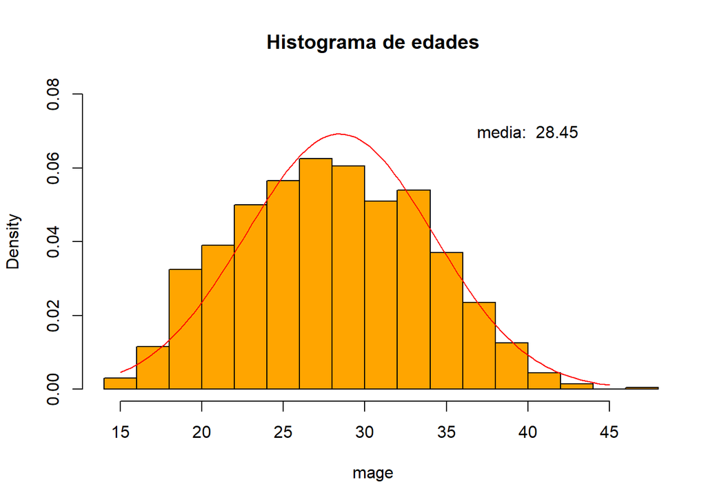

## 3.2. Semanas de gestación

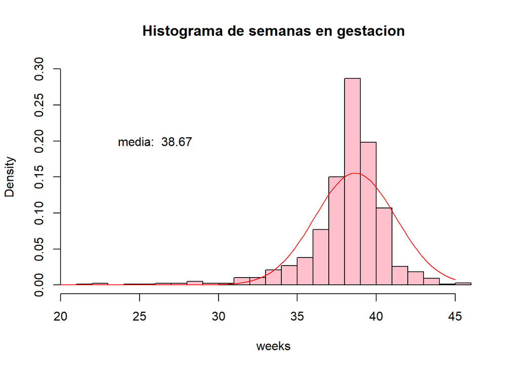

## 3.3. Clasificación de los nacimientos

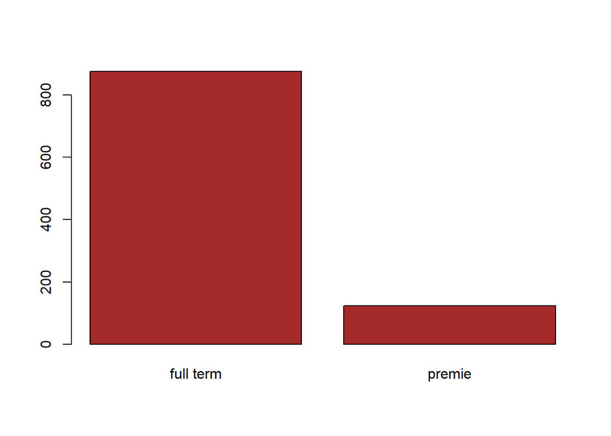

## 3.4. Visitas al hospital

En esta fila se encuentran 56 valores NA.

### 3.4.1. Omitiendo los valores NA

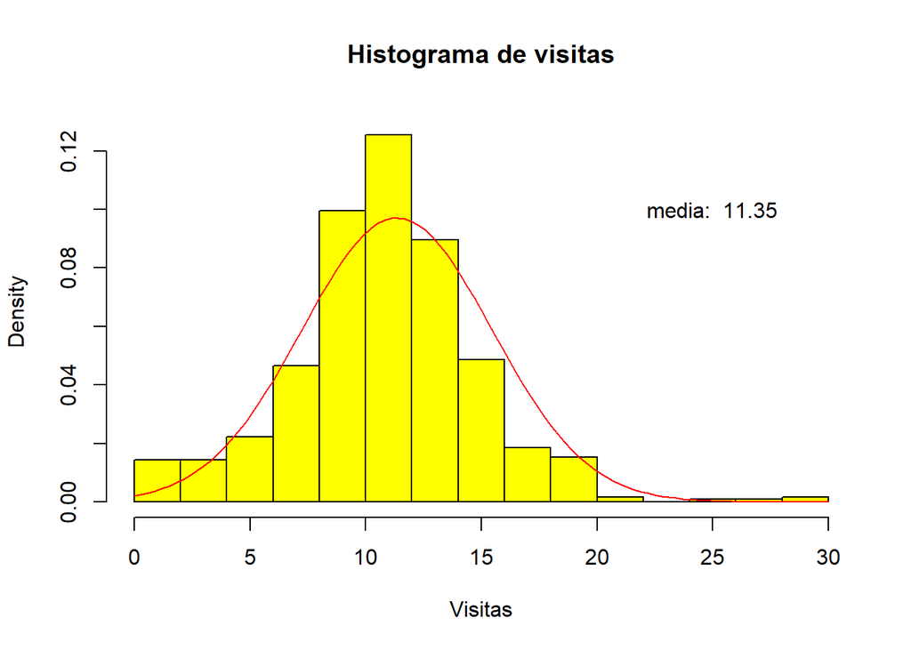

### 3.4.2. Tomando los valores NA como 0 visitas

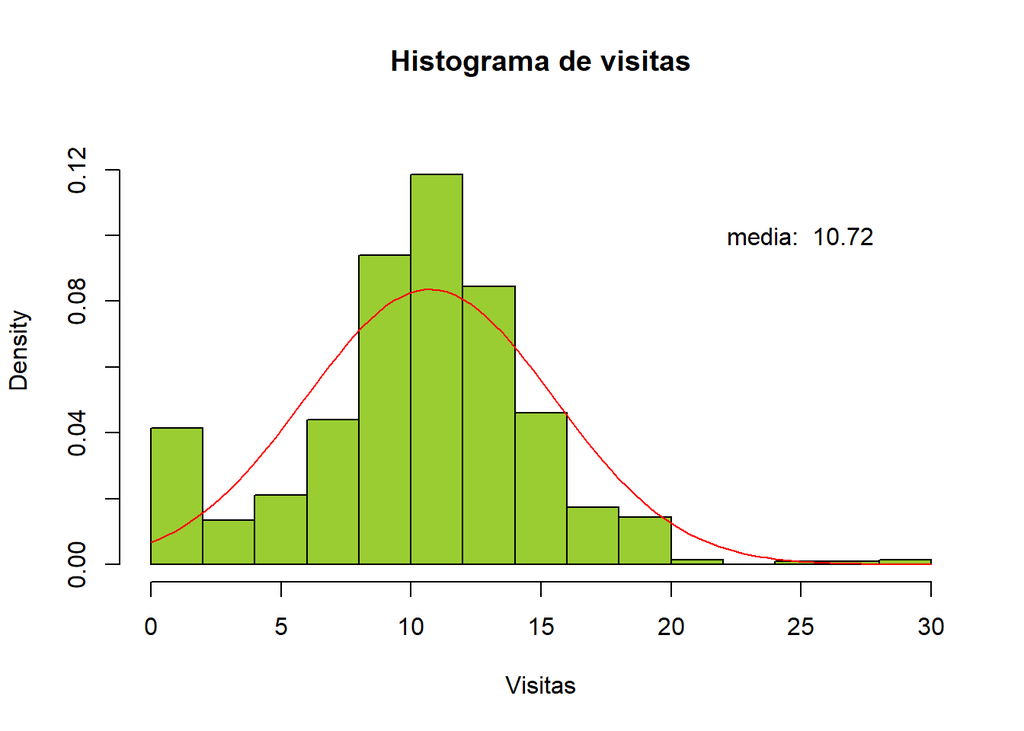

Consecuentemente, se eliminarán éstas 56 filas, para evitar valores atípicos en los datos para el estudio.

## 3.5. Peso ganado por la madre

Para este caso, se identifican 42 valores NA en el dataset.

### 3.5.1. Omitiendo los valores NA

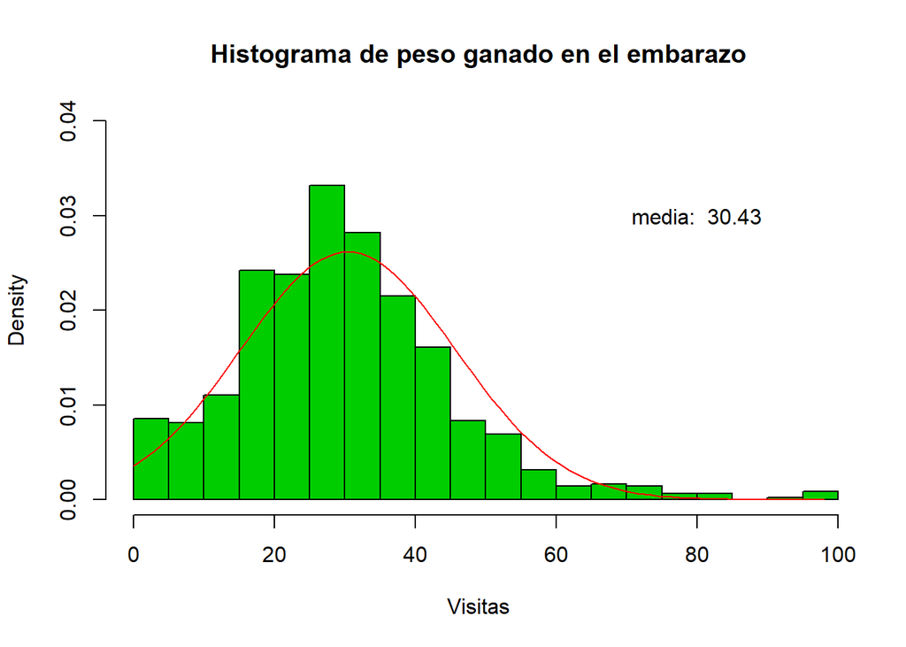

### 3.5.2. Tomando los valores NA como 0 libras

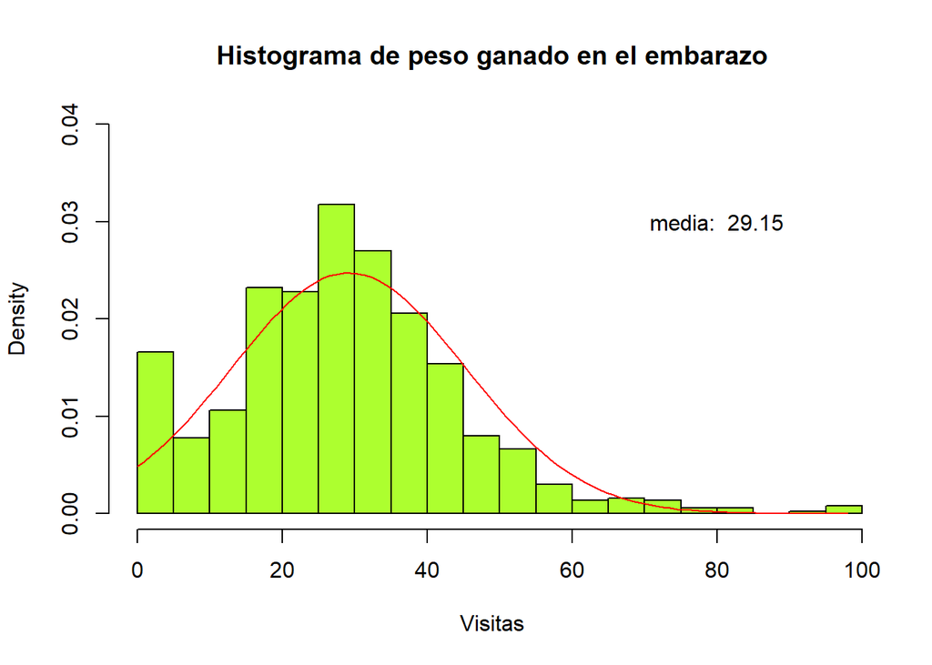

De igual forma que en el caso de las visitas, se eliminarán las filas con valores NA para el peso ganado.

## 3.6. Peso del bebé al nacer

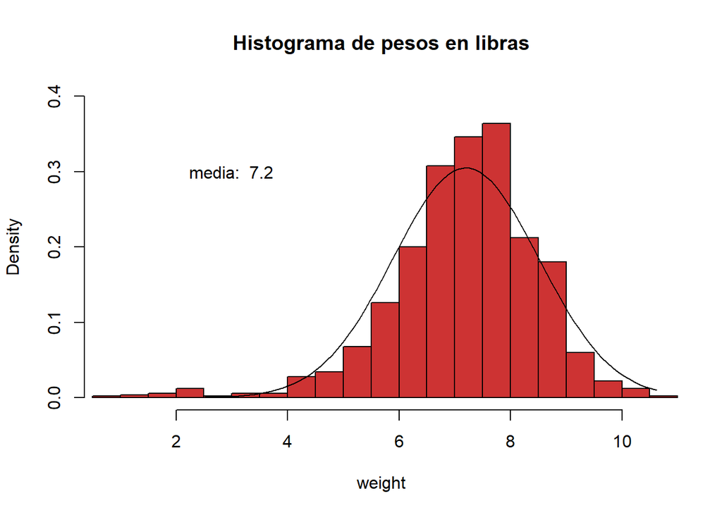

## 3.7. Clasificación del peso al nacer

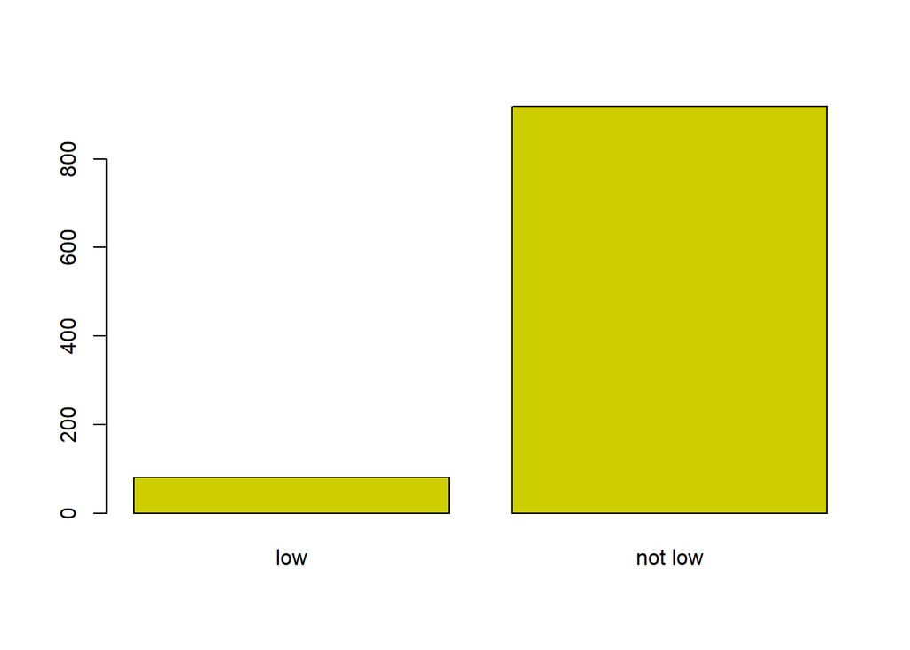

## 3.8. Clasificación del hábito de fumar de la madre

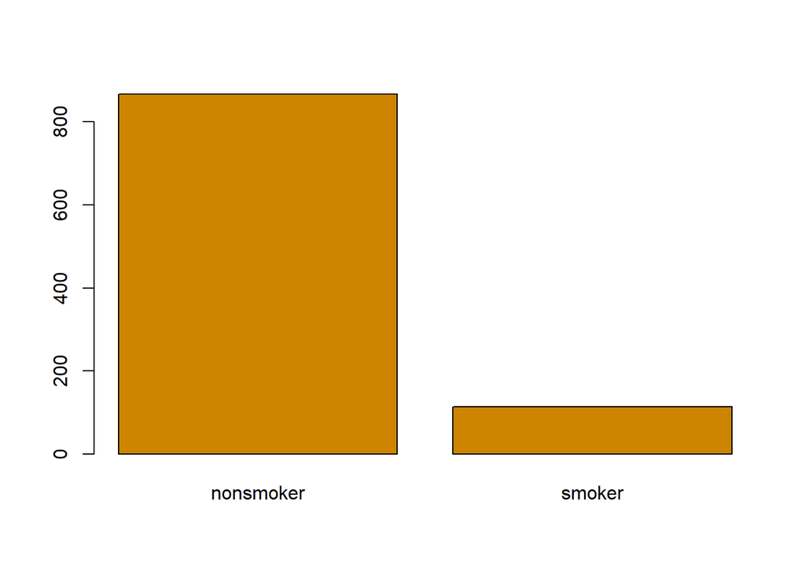

## 3.9. Limpieza y tratamiento del dataset

Inicialmente se convierten las variables categóricas de texto a un formato binario y se eliminan los valores NA.

```r
# "younger mom" = 0, "mature mom" = 1
df$mature <- ifelse(df$mature == "younger mom", 0, ifelse(df$mature == "mature mom", 1, df$mature))
df$mature <- as.numeric(df$mature)

# "full term" = 0, "premie" = 1
df$premie <- ifelse(df$premie == "full term", 0, ifelse(df$premie == "premie", 1, df$premie))
df$premie <- as.numeric(df$premie)

# "not low" = 0, "low" = 1
df$lowbirthweight <- ifelse(df$lowbirthweight == "not low", 0, ifelse(df$lowbirthweight == "low", 1, df$lowbirthweight))
df$lowbirthweight <- as.numeric(df$lowbirthweight)

# "male" = 0, "female" = 1
df$sex <- ifelse(df$sex == "male", 0, ifelse(df$sex == "female", 1, df$sex))
df$sex <- as.numeric(df$sex)

# "nonsmoker" = 0, "smoker" = 1
df$habit <- ifelse(df$habit == "nonsmoker", 0, ifelse(df$habit == "smoker", 1, df$habit))
df$habit <- as.numeric(df$habit)

# "not married" = 0, "married" = 1
df$marital <- ifelse(df$marital == "not married", 0, ifelse(df$marital == "married", 1, df$marital))
df$marital <- as.numeric(df$marital)

# "not white" = 0, "white" = 1
df$whitemom <- ifelse(df$whitemom == "not white", 0, ifelse(df$whitemom == "white", 1, df$whitemom))
df$whitemom <- as.numeric(df$whitemom)
```

```r
df <- subset(df, select = -fage)
df <- df[!is.na(df$visits), ]
df <- df[!is.na(df$gained), ]
df <- df[!is.na(df$habit), ]
```

# 4. Formulación, Selección y Evaluación de Modelos de Regresión

## 4.1. Peso del bebé en función del ganado por la madre

### 4.1.1. Regresión lineal simple

$$x = Peso\ ganado\ por\ la\ madre\ (mom\_gained)\\
y = Peso\ del\ bebé\ (birth\_weight)\\$$

```r
mom_gained <- df$gained
birth_weight <- df$weight

x_bar <- mean(mom_gained)
y_bar <- mean(birth_weight)

n = length(mom_gained)
print(paste("n =", n))
```

```
## [1] "n = 894"
```

### 4.1.2. Pendiente e intercepto para la recta de regresión

$$\hat{\beta_{1}}=\frac{\sum_{i=1}^{894}(x_i-\bar{x})(y_i-\bar{y})}{\sum_{i=1}^{894}(x_i-\bar{x})^{2}}\\
\hat{\beta_{0}}=\bar{y}-\hat{\beta_{1}}\bar{x}$$

```r
B1_est = sum((mom_gained-x_bar)*(birth_weight-y_bar))/sum((mom_gained-x_bar)**2)
B0_est = y_bar - (B1_est*x_bar)
```

### 4.1.3. Gráfica de los datos y curva de regresión

$$\hat{y}=\hat{\beta_{0}}+\hat{\beta_{1}}x=6.84+0.012x$$

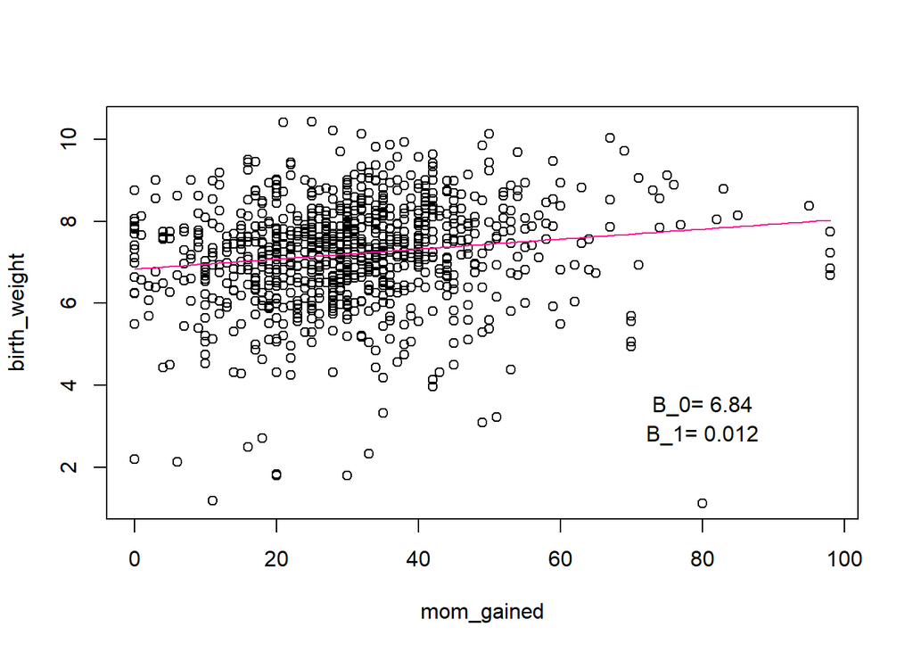

```r
plot(mom_gained, birth_weight)
curve(B0_est+B1_est*x, add = TRUE, col = "deeppink")
text(80, 3.5, paste("B_0=", round(B0_est, 2)))
text(80, 2.8, paste("B_1=", round(B1_est, 3)))
```

### 4.1.4. Varianza residual

```r
errors = birth_weight - (B0_est+(B1_est*mom_gained))
re_var = sum(errors**2)/(n-2)
```

La varianza residual es de 1.6024.

### 4.1.5. Coeficiente de determinación (R^2)

Usando la suma de cuadrados del error (SCE) y la suma total de cuadrados corregida (STCC):

```r
sce = sum(errors**2)
stcc = sum((birth_weight-y_bar)**2)

r2 = 1 - sce/stcc
r = cor(mom_gained, birth_weight)
```

El valor de R^2 es 0.0217 y el valor de R es 0.1472.

# 5. Conclusiones

## 5.1. Peso del bebé en función del ganado por la madre

- el 2% de la variabilidad en el peso del recién nacido, es explicado por el modelo.
- existe una correlación positiva y leve entre el peso del bebé y el ganado por la madre.